# Homework 1 - Data Science 3 - Exercise 2

Oscar Leal 1903161

3/9/2020

## 1. Tree ensemble models (7 points)

```r
data <- data.table(Hitters)
data <- data[!is.na(Salary)]
data[, log_salary := log(Salary)]
data[, Salary := NULL]
```

### Train two random forest models: one with mtry = 2 and another with mtry = 10 (use the whole dataset and don’t use cross-validation). Inspect variable importance profiles. What do you see in terms of how important the first few variables are relative to each other?

```r
# mtry = 2
tune_grid <- expand.grid(
  .mtry = 2,
  .splitrule = "variance",
  .min.node.size = c(5,7,10,12)
)

# run first model
set.seed(1234)
rf_mod1 <- train(log_salary ~ .,
                  method = "ranger",
                  data = data,
                  tuneGrid = tune_grid,
                  importance = "impurity"
                  )
rf_mod1
```

```
## Random Forest
##
## 263 samples
##  19 predictor
##
## No pre-processing
## Resampling: Bootstrapped (25 reps)
## Summary of sample sizes: 263, 263, 263, 263, 263, 263, ...
## Resampling results across tuning parameters:
##
##   min.node.size  RMSE       Rsquared   MAE
##    5             0.4369502  0.7642936  0.3045206
##    7             0.4392582  0.7619327  0.3064069
##   10             0.4389196  0.7627857  0.3065317
##   12             0.4402258  0.7621283  0.3078641
##
## Tuning parameter 'mtry' was held constant at a value of 2
## Tuning
##  parameter 'splitrule' was held constant at a value of variance
## RMSE was used to select the optimal model using the smallest value.
## The final values used for the model were mtry = 2, splitrule = variance
##  and min.node.size = 5.
```

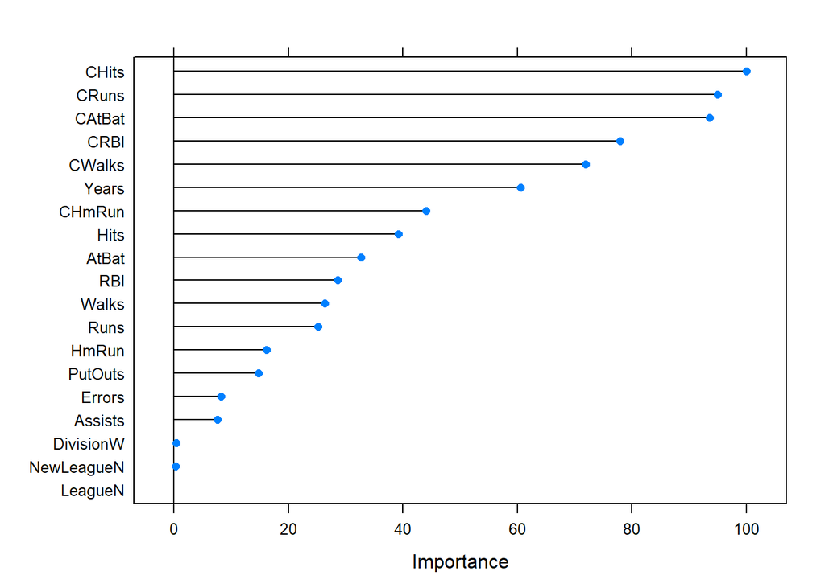

```r
plot(varImp(rf_mod1))
```

```r
#mtry 10
tune_grid2 <- expand.grid(
  .mtry = 10,
  .splitrule = "variance",
  .min.node.size = c(5,7,10)
)

# run second model
set.seed(1234)
rf_mod2 <- train(log_salary ~ .,
                  method = "ranger",
                  data = data,
                  tuneGrid = tune_grid2,
                  importance = "impurity"
                  )
rf_mod2
```

```
## Random Forest
##
## 263 samples
##  19 predictor
##
## No pre-processing
## Resampling: Bootstrapped (25 reps)
## Summary of sample sizes: 263, 263, 263, 263, 263, 263, ...
## Resampling results across tuning parameters:
##
##   min.node.size  RMSE       Rsquared   MAE
##    5             0.4462624  0.7509711  0.3095851
##    7             0.4460780  0.7514084  0.3094872
##   10             0.4466059  0.7507200  0.3092104
##
## Tuning parameter 'mtry' was held constant at a value of 10
## Tuning
##  parameter 'splitrule' was held constant at a value of variance
## RMSE was used to select the optimal model using the smallest value.
## The final values used for the model were mtry = 10, splitrule = variance
##  and min.node.size = 7.
```

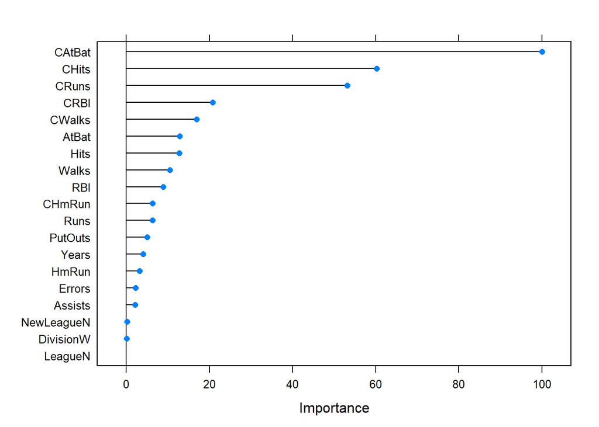

```r
plot(varImp(rf_mod2))
```

With mtry 2 it seems that the high (after the first one) importance variables have higher impact.

And when we try wih mtry 10, it seems that all of the rest except the first one are less significant.

### One of them is more extreme in terms of how the most important and the next ones relate to each other. Give an intuitive explanation how mtry relates to relative importance of variables in random forest models.

It seems that if there’s a higher mtry, the model will choose more accurately between the chosen variables which are the most important.

### In the same vein, estimate two gbm models and set bag.fraction to 0.1 first and to 0.9 in the second. The tuneGrid should consist of the same values for the two models (a dataframe with one row): n.trees = 500, interaction.depth = 5, shrinkage = 0.1, n.minobsinnode = 5. Compare variable importance plots for the two models. What is the meaning of bag.fraction? Based on this, why is one variable importance profile more extreme than the other?

```r
# set up tuning params that will be used for both models
gbm_grid <- expand.grid(n.trees = 500,
                        interaction.depth = 5,
                        shrinkage = 0.1,
                        n.minobsinnode = 5)

# first model
set.seed(5643)
gbm1 <- train(log_salary ~ .,
                   method = "gbm",
                   data = data,
                   tuneGrid = gbm_grid,
                   bag.fraction = 0.1,
                   verbose = FALSE
                   )
gbm1
```

```
## Stochastic Gradient Boosting
##
## 263 samples
##  19 predictor
##
## No pre-processing
## Resampling: Bootstrapped (25 reps)
## Summary of sample sizes: 263, 263, 263, 263, 263, 263, ...
## Resampling results:
##
##   RMSE      Rsquared   MAE
##   0.521975  0.6729626  0.3786346
##
## Tuning parameter 'n.trees' was held constant at a value of 500
## Tuning
##
## Tuning parameter 'shrinkage' was held constant at a value of 0.1
##
## Tuning parameter 'n.minobsinnode' was held constant at a value of 5
```

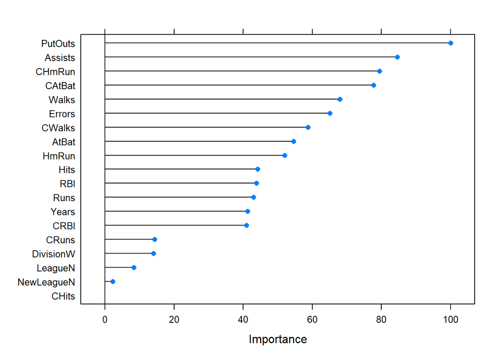

```r
plot(varImp(gbm1))
```

```r
# second model
set.seed(5643)
gbm2 <- train(log_salary ~ .,
                   method = "gbm",
                   data = data,
                   tuneGrid = gbm_grid,
                   bag.fraction = 0.9,
                   verbose = FALSE
                   )
gbm2
```

```
## Stochastic Gradient Boosting
##
## 263 samples
##  19 predictor
##
## No pre-processing
## Resampling: Bootstrapped (25 reps)
## Summary of sample sizes: 263, 263, 263, 263, 263, 263, ...
## Resampling results:
##
##   RMSE       Rsquared   MAE
##   0.4940025  0.6969913  0.3502631
##
## Tuning parameter 'n.trees' was held constant at a value of 500
## Tuning
##
## Tuning parameter 'shrinkage' was held constant at a value of 0.1
##
## Tuning parameter 'n.minobsinnode' was held constant at a value of 5
```

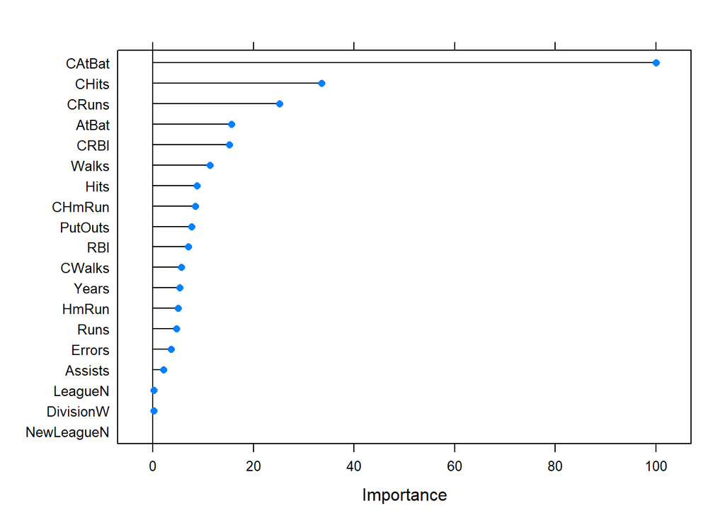

```r
plot(varImp(gbm2))
```

With gbm it can be concluded that the bag.fraction behaves like mtry but in an opposite way, the higher the fraction in the model, the less it will tend to take more variables as important.

The higher the variable importances of the model, the more variables it has to choose to estimate the importance of each individual case.